# EasyVisa_Full_Code_Notebook (1)

**Tuning Adaboost using undersampled data**

```python
AdaBoostClassifier().get_params()
```

```
{'algorithm': 'deprecated',
 'estimator': None,
 'learning_rate': 1.0,
 'n_estimators': 50,
 'random_state': None}
```

```python
%%time

# defining model
Model = AdaBoostClassifier(random_state=1)

# Parameter grid to pass in RandomSearchCV
param_grid = {
    "n_estimators": [150,200,250], ## Complete the code to set the number of estimators
    "learning_rate": [0.5], ## Complete the code to set the learning rate.
    "algorithm": ['SAMME'],       # Changed to 'SAMME' to be compatible with scikit-learn 1.5.2
    "estimator": [DecisionTreeClassifier(max_depth=1, random_state=1), DecisionTreeClassifier(max_depth=2, random_state=1), DecisionTreeClassifier(max_depth=3, random_state=1),
    ]
}

from sklearn.model_selection import RandomizedSearchCV

#Calling RandomizedSearchCV
randomized_cv = RandomizedSearchCV(estimator=Model, param_distributions=param_grid, n_iter=50, n_jobs = -1, scoring=scorer, cv=5, random_state=1)

#Fitting parameters in RandomizedSearchCV
randomized_cv.fit(X_train_un,y_train_un) ## Complete the code to fit the model on over sampled data

print("Best parameters are {} with CV score={}:" .format(randomized_cv.best_params_,randomized_cv.best_score_))
```

```
Best parameters are {'n_estimators': 150, 'learning_rate': 0.5, 'estimator': DecisionTreeClassifier(max_depth=3, random_state=1), 'algorithm': 'SAMME'} with CV score=0.6969028007748214:
CPU times: user 3.99 s, sys: 184 ms, total: 4.18 s
Wall time: 1min 56s
```

```python
## Complete the code to set the best parameters.
tuned_ada = AdaBoostClassifier(
    n_estimators=250, learning_rate=0.5, estimator=DecisionTreeClassifier(max_depth=2, random_state=1)
)

tuned_ada.fit(X_train_un, y_train_un)
```

```
AdaBoostClassifier(estimator=DecisionTreeClassifier(max_depth=2,
                                                    random_state=1),
                   learning_rate=0.5, n_estimators=250)
```

```python
# Checking model's performance on training set
ada_train_perf = model_performance_classification_sklearn(tuned_ada, X_train_un, y_train_un)
ada_train_perf


#Metrics Append
df_metrics = add_metric_row(df_metrics, ada_train_perf, "AdaBoost-Tuned", "Train", "Undersampled", "tuned_ada")
```

```python
## Complete the code to check the model performance for validation data.
ada_val_perf = model_performance_classification_sklearn(tuned_ada, X_val, y_val)
ada_val_perf

#Metrics Append
df_metrics = add_metric_row(df_metrics, ada_val_perf, "AdaBoost-Tuned", "Validation", "Undersampled", "tuned_ada")
```

```python
#Print df_metrics
df_metrics[(df_metrics['Model Name'].str.contains('AdaBoost-Tuned'))]
```

|  | Accuracy | Recall | Precision | F1 | Test/Train/Val | Model Name | Data Type | Model Variable |
| --- | --- | --- | --- | --- | --- | --- | --- | --- |
| 42 | 0.702094 | 0.670775 | 0.715598 | 0.692462 | Train | AdaBoost-Tuned | Undersampled | tuned_ada |
| 43 | 0.714940 | 0.675463 | 0.558632 | 0.611517 | Validation | AdaBoost-Tuned | Undersampled | tuned_ada |

```python
#Print df_metrics
df_metrics[(df_metrics['Model Name'].str.contains('AdaBoost'))]
```

|  | Accuracy | Recall | Precision | F1 | Test/Train/Val | Model Name | Data Type | Model Variable |
| --- | --- | --- | --- | --- | --- | --- | --- | --- |
| 6 | 0.735983 | 0.407901 | 0.667772 | 0.506446 | Train | AdaBoost | Original | AdaBoost_model_train_perf |
| 7 | 0.736525 | 0.401733 | 0.673267 | 0.503207 | Validation | AdaBoost | Original | AdaBoost_model_val_perf |
| 22 | 0.741962 | 0.539972 | 0.734669 | 0.622450 | Train | AdaBoost | Oversampled | AdaBoost1_model_train_perf |
| 23 | 0.727368 | 0.437968 | 0.628604 | 0.516249 | Validation | AdaBoost | Oversampled | AdaBoost1_model_val_perf |
| 34 | 0.690613 | 0.680398 | 0.694588 | 0.687420 | Train | AdaBoost | Undersampled | AdaBoost2_model_train_perf |
| 35 | 0.702643 | 0.692005 | 0.540948 | 0.607223 | Validation | AdaBoost | Undersampled | AdaBoost2_model_val_perf |
| 42 | 0.702094 | 0.670775 | 0.715598 | 0.692462 | Train | AdaBoost-Tuned | Undersampled | tuned_ada |
| 43 | 0.714940 | 0.675463 | 0.558632 | 0.611517 | Validation | AdaBoost-Tuned | Undersampled | tuned_ada |

** Observations **

** Tuning Gradient boost for undersampled data **

```python
GradientBoostingClassifier().get_params()
```

```
{'ccp_alpha': 0.0,
 'criterion': 'friedman_mse',
 'init': None,
 'learning_rate': 0.1,
 'loss': 'log_loss',
 'max_depth': 3,
 'max_features': None,
 'max_leaf_nodes': None,
 'min_impurity_decrease': 0.0,
 'min_samples_leaf': 1,
 'min_samples_split': 2,
 'min_weight_fraction_leaf': 0.0,
 'n_estimators': 100,
 'n_iter_no_change': None,
 'random_state': None,
 'subsample': 1.0,
 'tol': 0.0001,
 'validation_fraction': 0.1,
 'verbose': 0,
 'warm_start': False}
```

```python
%%time

# defining model
Model = GradientBoostingClassifier(random_state=1)

# Parameter grid to pass in RandomSearchCV
param_grid = {
    "n_estimators": [150,200,250],
    "min_samples_leaf": np.arange(5,10),
    "max_features": [np.arange(0.2,0.7,0.1),'sqrt'],
}

#Calling RandomizedSearchCV
randomized_cv = RandomizedSearchCV(estimator=Model, param_distributions=param_grid, n_iter=50, n_jobs = -1, scoring=scorer, cv=5, random_state=1) ## Complete the code to set the cv parameter

#Fitting parameters in RandomizedSearchCV
randomized_cv.fit(X_train_un,y_train_un) ## Complete the code to fit the model on under sampled data

print("Best parameters are {} with CV score={}:" .format(randomized_cv.best_params_,randomized_cv.best_score_))
```

```
Best parameters are {'n_estimators': 250, 'min_samples_leaf': np.int64(5), 'max_features': 'sqrt'} with CV score=0.7002765275579529:
CPU times: user 2.56 s, sys: 127 ms, total: 2.68 s
Wall time: 1min 17s
```

```python
# Complete the code to define the best model
tuned_GB2 = GradientBoostingClassifier(
    max_features='sqrt',
    random_state=1,
    n_estimators=150,
    min_samples_leaf=9,
)

tuned_GB2.fit(X_train_un, y_train_un)
```

```
GradientBoostingClassifier(max_features='sqrt', min_samples_leaf=9,
                           n_estimators=150, random_state=1)
```

```python
# Checking model's performance on training set

GB3_train_perf = model_performance_classification_sklearn(
    tuned_GB2, X_train_un, y_train_un
)
GB3_train_perf

#Metrics Append
df_metrics = add_metric_row(df_metrics, GB3_train_perf, "GradientBoost-Tuned", "Train", "Undersampled", "tuned_GB2")
```

```python
# Checking model's performance on validation set
GB3_val_perf = model_performance_classification_sklearn(
    tuned_GB2, X_val, y_val
)
GB3_val_perf

#Metrics Append
df_metrics = add_metric_row(df_metrics, GB3_val_perf, "GradientBoost-Tuned", "Validation", "Undersampled", "tuned_GB2")
```

```python
#Print df_metrics
df_metrics[(df_metrics['Model Name'].str.contains('GradientBoost-Tuned'))]
```

|  | Accuracy | Recall | Precision | F1 | Test/Train/Val | Model Name | Data Type | Model Variable |
| --- | --- | --- | --- | --- | --- | --- | --- | --- |
| 44 | 0.718302 | 0.691879 | 0.730481 | 0.710656 | Train | GradientBoost-Tuned | Undersampled | tuned_GB2 |
| 45 | 0.718080 | 0.689248 | 0.561617 | 0.618921 | Validation | GradientBoost-Tuned | Undersampled | tuned_GB2 |

```python
#Print df_metrics
df_metrics[(df_metrics['Model Name'].str.contains('GradientBoost'))]
```

|  | Accuracy | Recall | Precision | F1 | Test/Train/Val | Model Name | Data Type | Model Variable |
| --- | --- | --- | --- | --- | --- | --- | --- | --- |
| 8 | 0.754822 | 0.512240 | 0.671536 | 0.581170 | Train | GradientBoost | Original | GradientBoosting_model_train_perf |
| 9 | 0.751047 | 0.505711 | 0.664596 | 0.574368 | Validation | GradientBoost | Original | GradientBoosting_model_val_perf |
| 24 | 0.765110 | 0.626501 | 0.737682 | 0.677561 | Train | GradientBoost | Oversampled | GradientBoosting_model1_train_perf |
| 25 | 0.743982 | 0.533675 | 0.636748 | 0.580673 | Validation | GradientBoost | Oversampled | GradientBoosting_model1_val_perf |
| 36 | 0.719230 | 0.687321 | 0.734175 | 0.709976 | Train | GradientBoost | Undersampled | GradientBoosting_model2_train_perf |
| 37 | 0.719126 | 0.681371 | 0.563885 | 0.617086 | Validation | GradientBoost | Undersampled | GradientBoosting_model2_val_perf |
| 44 | 0.718302 | 0.691879 | 0.730481 | 0.710656 | Train | GradientBoost-Tuned | Undersampled | tuned_GB2 |
| 45 | 0.718080 | 0.689248 | 0.561617 | 0.618921 | Validation | GradientBoost-Tuned | Undersampled | tuned_GB2 |

**Observations**

** Tuning AdaBoost using Oversampled data **

```python
%%time

# defining model
Model = AdaBoostClassifier(random_state=1)

# Parameter grid to pass in RandomSearchCV, but
param_grid = {
    "n_estimators": [150,200,250], ## Complete the code to set the number of estimators
    "learning_rate": [0.5], ## Complete the code to set the learning rate.
    "algorithm": ['SAMME'],       # Changed to 'SAMME' to be compatible with scikit-learn 1.5.2
    "estimator": [DecisionTreeClassifier(max_depth=1, random_state=1), DecisionTreeClassifier(max_depth=2, random_state=1), DecisionTreeClassifier(max_depth=3, random_state=1),
    ]
}


#Calling RandomizedSearchCV
randomized_cv = RandomizedSearchCV(estimator=Model, param_distributions=param_grid, n_iter=50, n_jobs = -1, scoring=scorer, cv=5, random_state=1)

#Fitting parameters in RandomizedSearchCV
randomized_cv.fit(X_train_over,y_train_over) ## Complete the code to fit the model on over sampled data

print("Best parameters are {} with CV score={}:" .format(randomized_cv.best_params_,randomized_cv.best_score_))
```

```
Best parameters are {'n_estimators': 200, 'learning_rate': 0.5, 'estimator': DecisionTreeClassifier(max_depth=3, random_state=1), 'algorithm': 'SAMME'} with CV score=0.64002402125116:
CPU times: user 9.07 s, sys: 258 ms, total: 9.32 s
Wall time: 2min 59s
```

```python
## Complete the code to set the best parameters.
tuned_ada1 = AdaBoostClassifier(
    n_estimators=250, learning_rate=0.5, estimator=DecisionTreeClassifier(max_depth=2, random_state=1)
)

tuned_ada1.fit(X_train_over, y_train_over)
```

```
AdaBoostClassifier(estimator=DecisionTreeClassifier(max_depth=2,
                                                    random_state=1),
                   learning_rate=0.5, n_estimators=250)
```

** Comparing the performance Metrics **

```python
# Checking model's performance on training set
ada_train_perf = model_performance_classification_sklearn(tuned_ada1, X_train_un, y_train_un)
ada_train_perf


#Metrics Append
df_metrics = add_metric_row(df_metrics, ada_train_perf, "AdaBoost-Tuned", "Train", "Oversampled", "tuned_ada1")
```

```python
## Complete the code to check the model performance for validation data.
ada_val_perf = model_performance_classification_sklearn(tuned_ada, X_val, y_val)
ada_val_perf

#Metrics Append
df_metrics = add_metric_row(df_metrics, ada_val_perf, "AdaBoost-Tuned", "Validation", "Oversampled", "tuned_ada1")
```

```python
#Print df_metrics
df_metrics[(df_metrics['Model Name'].str.contains('AdaBoost'))]
```

|  | Accuracy | Recall | Precision | F1 | Test/Train/Val | Model Name | Data Type | Model Variable |
| --- | --- | --- | --- | --- | --- | --- | --- | --- |
| 6 | 0.735983 | 0.407901 | 0.667772 | 0.506446 | Train | AdaBoost | Original | AdaBoost_model_train_perf |
| 7 | 0.736525 | 0.401733 | 0.673267 | 0.503207 | Validation | AdaBoost | Original | AdaBoost_model_val_perf |
| 22 | 0.741962 | 0.539972 | 0.734669 | 0.622450 | Train | AdaBoost | Oversampled | AdaBoost1_model_train_perf |
| 23 | 0.727368 | 0.437968 | 0.628604 | 0.516249 | Validation | AdaBoost | Oversampled | AdaBoost1_model_val_perf |
| 34 | 0.690613 | 0.680398 | 0.694588 | 0.687420 | Train | AdaBoost | Undersampled | AdaBoost2_model_train_perf |
| 35 | 0.702643 | 0.692005 | 0.540948 | 0.607223 | Validation | AdaBoost | Undersampled | AdaBoost2_model_val_perf |
| 42 | 0.702094 | 0.670775 | 0.715598 | 0.692462 | Train | AdaBoost-Tuned | Undersampled | tuned_ada |
| 43 | 0.714940 | 0.675463 | 0.558632 | 0.611517 | Validation | AdaBoost-Tuned | Undersampled | tuned_ada |
| 46 | 0.685632 | 0.529461 | 0.769948 | 0.627451 | Train | AdaBoost-Tuned | Oversampled | tuned_ada1 |
| 47 | 0.714940 | 0.675463 | 0.558632 | 0.611517 | Validation | AdaBoost-Tuned | Oversampled | tuned_ada1 |

** Observations **

```python
RandomForestClassifier().get_params()
```

```
{'bootstrap': True,
 'ccp_alpha': 0.0,
 'class_weight': None,
 'criterion': 'gini',
 'max_depth': None,
 'max_features': 'sqrt',
 'max_leaf_nodes': None,
 'max_samples': None,
 'min_impurity_decrease': 0.0,
 'min_samples_leaf': 1,
 'min_samples_split': 2,
 'min_weight_fraction_leaf': 0.0,
 'monotonic_cst': None,
 'n_estimators': 100,
 'n_jobs': None,
 'oob_score': False,
 'random_state': None,
 'verbose': 0,
 'warm_start': False}
```

```python
%%time

# defining model
Model = RandomForestClassifier(random_state=1)

# Parameter grid to pass in RandomSearchCV
param_grid = {
    "n_estimators": [150,200,250], ## Complete the code to set the number of estimators.
    "min_samples_leaf": np.arange(5,10),## Complete the code to set the minimum number of samples in the leaf node.
    "max_features": [np.arange(0.2,0.7,0.1),'sqrt'], ## Complete the code to set the maximum number of features.
    "max_samples": np.arange(0.3,0.7,0.1)} ## Complete the code to set the maximum number of samples.


#Calling RandomizedSearchCV
randomized_cv = RandomizedSearchCV(estimator=Model, param_distributions=param_grid, n_iter=50, n_jobs = -1, scoring=scorer, cv=5, random_state=1) ## Complete the code to set the cv parameter

#Fitting parameters in RandomizedSearchCV
randomized_cv.fit(X_train_un,y_train_un) ## Complete the code to fit the model on under sampled data

print("Best parameters are {} with CV score={}:" .format(randomized_cv.best_params_,randomized_cv.best_score_))
```

```
Best parameters are {'n_estimators': 150, 'min_samples_leaf': np.int64(7), 'max_samples': np.float64(0.6000000000000001), 'max_features': 'sqrt'} with CV score=0.6950274187582451:
CPU times: user 3.8 s, sys: 392 ms, total: 4.19 s
Wall time: 2min 48s
```

```python
# Complete the code to define the best model
tuned_rf2 = RandomForestClassifier(
    max_features='sqrt',
    random_state=1,
    max_samples=0.6,
    n_estimators=200,
    min_samples_leaf=5,
)

tuned_rf2.fit(X_train_un, y_train_un)
```

```
RandomForestClassifier(max_samples=0.6, min_samples_leaf=5, n_estimators=200,
                       random_state=1)
```

** Compare the performance score of the model **

```python
rf2_train_perf = model_performance_classification_sklearn(
    tuned_rf2, X_train_un, y_train_un
)
rf2_train_perf

#Metrics Append
df_metrics = add_metric_row(df_metrics, rf2_train_perf, "RandomForest-Tuned", "Train", "Undersampled", "rf2_train_perf")
```

```python
## Complete the code to print the model performance on the validation data.
rf2_val_perf = model_performance_classification_sklearn(tuned_rf2,X_val,y_val)
rf2_val_perf

#Metrics Append
df_metrics = add_metric_row(df_metrics, rf2_val_perf, "RandomForest-Tuned", "Validation", "Undersampled", "rf2_val_perf")
```

```python
#Print df_metrics
df_metrics[(df_metrics['Model Name'].str.contains('RandomForest'))]
```

|  | Accuracy | Recall | Precision | F1 | Test/Train/Val | Model Name | Data Type | Model Variable |
| --- | --- | --- | --- | --- | --- | --- | --- | --- |
| 48 | 0.761101 | 0.731217 | 0.777698 | 0.753742 | Train | RandomForest-Tuned | Undersampled | rf2_train_perf |
| 49 | 0.722004 | 0.683340 | 0.567736 | 0.620197 | Validation | RandomForest-Tuned | Undersampled | rf2_val_perf |

** Observations **

## Model Performance Summary and Final Model Selection

```python
#Training Set performance on Tuned Model
#Print df_metrics for 'Model Values' containing string Tuned
df_metrics[(df_metrics['Model Name'].str.contains('Tuned')) & (df_metrics['Test/Train/Val'].str.contains('Train'))]
```

|  | Accuracy | Recall | Precision | F1 | Test/Train/Val | Model Name | Data Type | Model Variable |
| --- | --- | --- | --- | --- | --- | --- | --- | --- |
| 40 | 0.734638 | 0.589904 | 0.602622 | 0.596195 | Train | Decision Tree-Tuned | Original | dtree_tuned1 |
| 42 | 0.702094 | 0.670775 | 0.715598 | 0.692462 | Train | AdaBoost-Tuned | Undersampled | tuned_ada |
| 44 | 0.718302 | 0.691879 | 0.730481 | 0.710656 | Train | GradientBoost-Tuned | Undersampled | tuned_GB2 |
| 46 | 0.685632 | 0.529461 | 0.769948 | 0.627451 | Train | AdaBoost-Tuned | Oversampled | tuned_ada1 |
| 48 | 0.761101 | 0.731217 | 0.777698 | 0.753742 | Train | RandomForest-Tuned | Undersampled | rf2_train_perf |

```python
#Validation Set performance on Tuned Model
#Print df_metrics for 'Model Values' containing string Tuned
df_metrics[(df_metrics['Model Name'].str.contains('Tuned')) & (df_metrics['Test/Train/Val'].str.contains('Validation'))]
```

|  | Accuracy | Recall | Precision | F1 | Test/Train/Val | Model Name | Data Type | Model Variable |
| --- | --- | --- | --- | --- | --- | --- | --- | --- |
| 41 | 0.739273 | 0.602993 | 0.608506 | 0.605737 | Validation | Decision Tree-Tuned | Original | dtree_tuned1 |
| 43 | 0.714940 | 0.675463 | 0.558632 | 0.611517 | Validation | AdaBoost-Tuned | Undersampled | tuned_ada |
| 45 | 0.718080 | 0.689248 | 0.561617 | 0.618921 | Validation | GradientBoost-Tuned | Undersampled | tuned_GB2 |
| 47 | 0.714940 | 0.675463 | 0.558632 | 0.611517 | Validation | AdaBoost-Tuned | Oversampled | tuned_ada1 |
| 49 | 0.722004 | 0.683340 | 0.567736 | 0.620197 | Validation | RandomForest-Tuned | Undersampled | rf2_val_perf |

** Observations **

** Final Performance score on top two selected **

** Adaboost Tuned score **

```python
## Complete the code to print the model performance on the test data by the best model.
test = model_performance_classification_sklearn(tuned_ada, X_test, y_test)
test
```

|  | Accuracy | Recall | Precision | F1 |
| --- | --- | --- | --- | --- |
| 0 | 0.71494 | 0.675463 | 0.558632 | 0.611517 |

** Gradient boost Tuned **

```python
## Complete the code to print the model performance on the test data by the best model.
test = model_performance_classification_sklearn(tuned_GB2, X_test, y_test)
test
```

|  | Accuracy | Recall | Precision | F1 |
| --- | --- | --- | --- | --- |
| 0 | 0.71808 | 0.689248 | 0.561617 | 0.618921 |

Observations:

1. Both ADABoost and GradientBoost are showing similar performance. Gradientboost is slightly better on test data (Recall 0.67 for AdaBoost vs 0.68 for Gradient Boost).
2. Additionally F1 is an important score evaluation of the model, greater the F1 score higher are the chances of minimizing False Negatives and False Positives.That would mean we will have lesser inelgible candidates marked as eligible and vise versa. F1 score is 0.6 for both models. Selecting Gradientboost gives better Recall and F1.

** Feature importance **

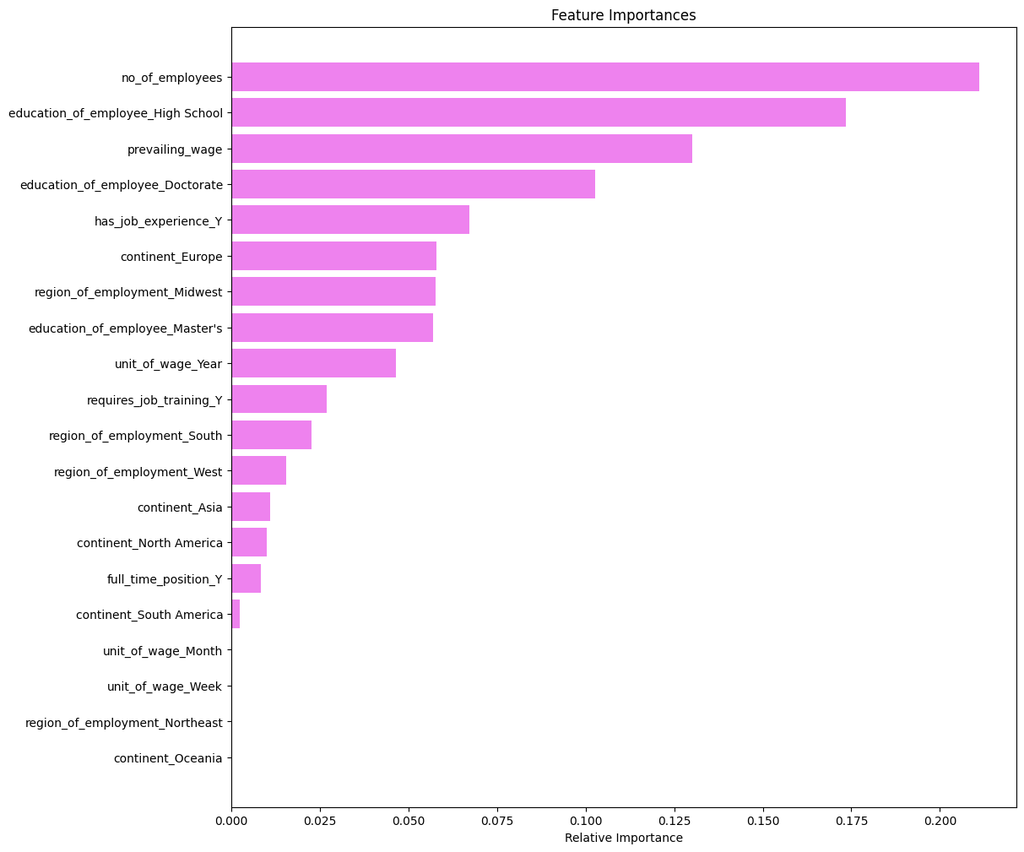

```python
feature_names = X_train.columns
importances = tuned_ada.feature_importances_
indices = np.argsort(importances)

plt.figure(figsize=(12, 12))
plt.title("Feature Importances")
plt.barh(range(len(indices)), importances[indices], color="violet", align="center")
plt.yticks(range(len(indices)), [feature_names[i] for i in indices])
plt.xlabel("Relative Importance")
plt.show()
```

## Actionable Insights and Recommendations

Power Ahead

** Key Data Insights (Univariate and Bivariate Analysis) **

1. The dataset has 25480 rows and 12 columns, with no dulicates and no missing values.
2. The dataset has 3 numerical fields and 9 object type fields, which were converted to numeric type by using encoding dummies.
3. There are some negative values in 'no_of_employees' field, that were corrected using absolute values (data cleansing)
4. It seems some companies have fairly large employee count, with maximum employees as 602069 for a company.
5. Mean wage is 74455.81, but as minimum is 2.137, which mean unit_of_wage (hourly, weekly, monthly, yearly) is an important parameter for modeling. 'Continent' has 6 unique values, with highest volume from Asia (16861) and lowest from Oceania (192)
6. Maximum number of applicants have highest education as bachelors (10234). 10678 applicants have no job experience but only 2955 requires job training. ~40% of the applicants are having bachelor's degree and ~38% of them have Master's degree. ~46% of the applications are having higher education (Masters or Doctorate) ~58% of the applicants have job application. ~33% of the applicants are denied. There is no major correlation between no_of_employees, yr_of_estab and prevailing_wage of the applicants.
7. Applicants with higher education have higher approval chance. They may be travelling abroad for a well-paid job.
8. Asia has maximum number of applicants and thus also has highest number of approvals. ~65% (11012 applicants) of total approvals (17018) are from Asia region.Europe region has maximum approval rate. ~80% of the European applicants are getting approved, while this certified rate is ~65% for Asian applicants. Experienced professionals may look abroad for opportunities to have better career opportunities. The data says that we have higher visa certification for applicants with job experience (74%) versus applicants without job experience (54%).
9. Prevailing wages is higher for Island (mostly hourly wages). Monthly salary is higher in Midwest compared to other regions
10. Visa approval rate is slightly higher for applicants with higher salary.
11. Important to note that 90% of the applicants have yearly salary, but there are some applicants who reported hourly, weekly and monthly.The yearly prevailing wage has nearly 70% approval rate (against hourly salary that has ~35% approval)
12. Applicants from Midwest have highest chance of approval, whereas applicants from Island have lowest chance of approval

** Model Building **

** Evaluation Criteria:**

```
1. Predicting an applicant is eligible for visa, but actually not eligible (False positive-FP). This will result in a qualified applicant to miss job opportunity.
2. Predicting an applicant is not eligible for visa(denied), but actually is eligible (False Negative-FN). This will also result in a qualified job applicant to miss job opportunity.
```

**Which metrics to optimize?**

1. We would want Recall and F1 to be maximized, the greater Recall, higher the changes of minimizing false negatives.
2. Recall is likely the most important metric in predicting visa eligibility, as failing to identify an eligible applicant would mean losing on potential candidate.
3. In addition F1 score is also an important parameter to reduce FP and FNs.
4. This will ensure that a potential applicant who might otherwise contribute positively to the country is not being unfairly rejected.
5. Missing eligible applicants could mean missing out on valuable candidates, such as skilled professionals or students.
6. On the other hand, if there are ineligible candidate, who are marked as eligible, there are other subsequent screening steps that can filter them out.

Hence, We would want to focus on Recall and F1 score.

** Model Building Approach **

```
** Undersampled data:**
1.  We compared six models on original data, oversampled data and undersampled data. After building 18 models (6 X 3), it was observed that both GBM and Adaboost models, trained on an undersampled dataset, exhibited strong performance on both the training and validation datasets
** Drop in scores:**
1. When seeing the drop of scores (F1 and Recall) from train set to validation set, the top two models are AdaBoost and Gradient Boost.
** Hypertuning: **
1. Sometimes models might overfit after undersampling and oversampling, so it's better to tune the models to get a generalized performance. We performed hypertuning on 5 models
  * Decision Tree (original data)
  * AdaBoost (undersampled data and oversampled both)
  * GradientBoost(undersampled data)
  * RandomForest (undersampled)
2. As we have noticed earlier, the top two models with oversampled data are also Gradient Boost and AdaBoost (comparing the difference of train and validation recall scores)
** Test Data:**
1. Tuned models were applied to unseen test data. Both ADABoost and GradientBoost are showing similar performance.

**Final Model selected **
**Gradientboost as it had better f1 and recall score**
```

** Business Insights**

** Business Recommendation **

1. It is recommended to have a "pre-screening" process or an automated tool that can use these top predictive features to score candidates on visa eligibility before moving forward. This helps prioritize high-potential applicants.
2. Employer Vetting Process: Ensure that the employer is in a favorable position for visa approval by validating parameters like number of employees, unit of wage, salary etc.
3. Business can focus on talent sourcing, partnerships, and marketing efforts on countries/regions with historically higher approval rates (Asia, Europe, North America) and large or reputable employers in the Midwest and South regions.
4. Business should continuouly evolve the model year on year with additional data as market condition and availability of candidates may change over time.